# 시사상식용어 정리

2018-01-29 15:08:00

최근 신문에 자주 거론되는 시사상식 용어를 정리해보았다.

## 산업 관련 용어

### 옴니채널

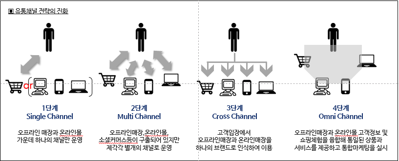

유통채널의 변화

온∙오프라인 채널을 넘나들며 구매하는 소비패턴을 의미함. 온라인, 오프라인에만 국한 시키지 않고, 자유롭게 구매 채널을 선택할 수 있으며, 다양한 플랫폼에 의해 구매할 수 있게 된다.

### 쇼루밍

오프라인 매장에서 상품을 보고 구매는 온라인에서 하는 쇼핑패턴을 말한다.

소비자들이 쇼루밍을 하는 이유는 오프라인 매장에서 얻고자 하는 상품과 서비스를 직접 체험하기 위해서다. 오프라인 구매의 가장 큰 장점 중 한 가지는 바로 소비자가 현장에서 바로 상품을 가져갈 수 있다는 점이다.

- 더 자세한 내용은 이 기사 참고하기 바람. [“옴니채널로 바뀐 소비1 트렌드”](http://www.nielsen.com/kr/ko/insights/2014/column-omni-channel.html)

## 금융 관련 용어

### 예대율(預貸率, loan-deposit ratio)

은행이 보유하고 있는 예금 잔액에 대해 은행이 빌려준 대출금 잔액의 비율을 의미하는 경제 용어다. 예금 대(VS) 대출금의 비율을 의미한다. 일반적으로 백분비(%)로 표시한다. 예대율이 높아지면, 대출을 줄이고, 예금을 더 많이 받아야한다. 즉, 은행의 자본이 더 많아져야한다는 의미이다. 경기과열 시 예대율을 조정하여 시장 긴장을 완화시킨다.

- 더 자세한 내용은 이 기사 참고하기 바람. [“고위험 LTV 위험가중치를 높이고, 가계대출에 예대율 가중치 15% 적용한다.”](http://news.hankyung.com/article/2018011977636)

### 모기지론

주택자금 수요자가 은행을 비롯한 금융기관에서 장기 저리자금을 빌리면 은행은 주택을 담보로 주택저당증권(MBS)을 발행, 이를 중개기관에 팔아 대출자금을 회수한다. 중개기관은 MBS를 다시 투자자에게 판매하고 그 대금을 금융기관에 지급하는 시스템이다.

주택금융공사가 주택저당채권(MBS)을 팔아 조달한 돈을 낮은 고정 금리로 빌려 주고 10년 이상 장기간에 걸쳐 원리금을 나눠 갚게 하는 제도. 이 제도가 되면 6억원 이상의 고급주택을 빼고 최고 2억원 한도 안에서 집값의 최고 70%까지 대출받을 수 있게 된다.

### 헤지펀드

100명 미만의 투자자를 모아 펀드를 만든 뒤 주식 채권 통화 파생금융상품 등 금융상품에 투자하거나 원유 금 등 실물자산을 매매해 이익을 남기는 투자 파트너십.

고도의 금융기법으로 위험을 줄이거나 없애 시장과는 무관한 중립적 포지션을 가지고 운용되며 시장평균과 비교한 상대적 수익률이 아니라 미리 정한 절대적 수익률을 추구한다는 점이 가장 큰 특징이다.

## 사회현상 관련 용어

### 밀레니얼 세대

X세대의 뒤를 잇는 인구집단. 1980년대 초부터 2000년대 후반까지 출생한 세대를 주로 일컫는다. 이렇다 말할 뚜렷한 특징이 없으나, 대체적으로 1. 똑똑한 쇱를 하며, 2. 관계를 중요시 하며, 3. 새로운 콘텐츠를 좋아한다는 특징이 있다.

- 더 자세한 내용은 이 글 참고하기 바람. [“너네는 왜 그러는 거니, 밀레니얼 세대!”](https://brunch.co.kr/@sampartners/10)

### 소셜믹스

분양가구과 임대가구를 한데 섞은 계층혼화 제도.

- 더 자세한 내용은 이 기사 참고하기 바람 [“공공임대 아파트 소셜믹스 정책은 실패했는가”](http://biz.khan.co.kr/khan_art_view.html?artid=201801280948021&code=920202)

### 사회간접자본(SOC; Social Overhead Capital)

도로 항만 철도 등 어떤 제품을 생산하는 데 직접 사용되지는 않지만 생산활동에 간접적으로 도움을 주는 시설을 말한다.

사회간접자본에 대한 투자를 소홀히 하게 되면 교통체증 항만적체 등을 유발해 생산과 수출에 애로를 겪게 되며, 따라서 상품의 경쟁력이 저하되는 문제가 발생한다.

인천국제공항공사, 한국공항공사, 코레일, 교통안전공단, 도로교통공단, 부산항만공사, 여수광양항만공사, 수자원공사, LH공사 등이 이에 해당한다.

### 임금피크제

정년까지 고용을 유지하는 대신 일정 연령이 되면 생산성을 감안해 임금을 줄이는 제도.

이 제도는 특히 국내 기업의 임금제 특성상 장기근속한 고령자일수록임금부담이 높아 기업이 이들을 해고의 주요 대상으로 삼고 있는데 대한 대안으로 떠오르고 있다. 일본은 80년대말부터 이 제도를 활발하게 도입했으나 국내에서는 아직 초기 논의단계에 있으며 연공서열제가 아닌 연봉제를 시행하고 있는 서구에는 없는 제도다.

### 환경개선부담금제(環境改善負擔金制)

오염원인자 부담원칙에 따라 오염물질을 배출한 오염원인자에게 오염물질 처리비용을 부담토록 하는 제도. 부과대상자는 폐수나 대기오염물질을 많이 배출하는 호텔, 병원, 백화점, 수영장, 음식점 등의 건물과 경유자동차이며 지방자치단체는 이들로부터 3월과 9월 1년에 두 차례 부담금을 징수한다.

환경개선부담금이 면제되는 건물은 단독주택 아파트 등 공동주택, 160 m2 미만의 시설물․공장․창고․주차장 등이다.

지방자치단체가 징수한 환경개선부담금은 징수비용(징수금액 중 10%)을 제외하고는 전액 환경부의 환경개선 특별회계로 귀속되며 환경부는 이 자금으로 하수종말처리장이나 쓰레기매립지, 쓰레기소각로 등 환경기초시설을 건설하는 데 사용한다.

### 페이스북의 개인정보 정책

현재 페이스북은 사용자가 페이스북에 로그인한 상태에서 다른 사이트에 접속하면 그 사이트에서 이뤄진 검색기록을 수집하고, 수집한 데이터에 근거해 맞춤형 광고를 하고 있다. 한 페이스북 이용자가 페이스북에 접속한 채 여행 관련 사이트에 들어갔다면 페이스북은 이 정보를 이용해 회원이 다음에 접속했을 때 여행업체들의 광고를 노출하는 형식이다.

이러한 운영방식에 대해 독일은 지난 25일 “페이스북은 회원들의 정보를 불법 남용하고 있고, 이에 대해 수사를 하고 있다”며 “페이스북이 이를 시정하지 않으면 사용자 동의 없이 데이터를 수집하는 것을 금지할 수 있다”고 경고했다.

- 더 자세한 내용은 이 기사 참고하기 바람. [“유럽규제 직면한 페이스북, 개인정보보호 강화대책 필요…”](http://news.hankyung.com/article/201801291164Y)

## 사회 정치 관련 용어

### 포괄적 네거티브

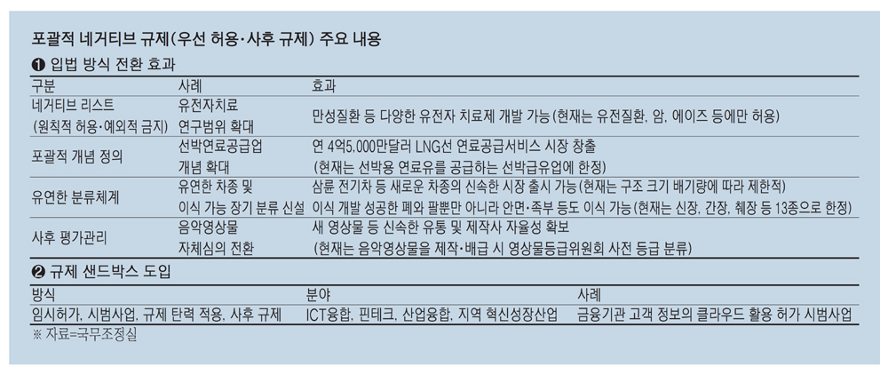

포괄적 네거티브 규제 주요내용

사전에 규제하던 것을 사후규제로 바꾸는 것.

- 네거티브 규제 : *허용*을 원칙으로 하되, *금지* 항목을 명시하고 규제
- 포시티브 규제 : *금지*를 원칙으로 하되, *허용* 항목을 명시하고 규제

이전 정부까지는 신제품이나 신사업에 대한 ‘허용’을 원칙으로 하되 금지하는 것을 법에 정하는 ’요건 나열식 네거티브’ 방식이었다면, 포괄적 네거티브는 한 발짝 더 나아가 신산업·신기술을 법령개정 없이도 이용할 수 있도록 입법방식을 유연화하는 것이다.

규제와 관련한 주요 개념 및 용어의 정의를 현재는 없지만 추후 등장할 수 있는 산업과 기술까지 포함하는 ‘포괄적’ 개념으로 수정하고, 유연한 제품·서비스 분류와 더불어 유연한 입법방식 등을 도입하기로 한 것이다. 이렇게 되면 신산업, 신기술 개발이 훨씬 수월해진다.

- 더 자세한 내용은 이 기사 참고하기 바랍. [관련 상세 뉴스](http://www.yonhapnews.co.kr/bulletin/2017/10/18/0200000000AKR20171018176200001.HTML)

### 규제 샌드박스

신사업에 한해 규제를 완화하겠다는 의미

어린이들이 자유롭게 노는 놀이터의 모래밭처럼 일정한 환경에서 규제를 풀어 신사업을 테스트할 수 있게 하는 것을 뜻한다. 규제 샌드박스는 영국에서 핀테크 산업 육성을 위해 최초로 시도했다.

현재 우리나라 규제 샌드박스를 시행하겠다고 하는데, 이는 혁신적인 제품·서비스에 대해 시범사업, 즉 임시허가를 내주고 기존 규제를 탄력적으로 면제·유예·완화해주는 방식을 도입한다. 시범사업에 문제가 있으면 사후규제를 하겠다는 것이다.

### 세이프 가드

긴급수입제한조치. 현재 트럼프가 자국 시장 보호를 이유로우리나라에 대해 세이프가드를 시행하려 한다. 이에 따라 우리나의 세탁기 시장과 태양열 시장이 위축될 것으로 전망된다.

- 관련기사 [“트럼프의 비상식적 세이프가드, WTO 제소가 정답”](http://news.joins.com/article/22325180)
- 관련기사 [“미국, 세이프가드 발동… 삼성과 LG세탁기 가격 20% 이상 오른다”](http://www.hani.co.kr/arti/international/america/828939.html)

## 에너지 관련 용어

### DR제도

DR제도는 에너지 수급 상황을 실시간으로 측정하고 사용 현황과 수요를 파악해 전력 피크 시간대에 에너지 사용이 몰리는 현상을 완화시켜주는 프로그램이다. DR제도에 참여한 기업은 전력사용 감축 등을 통해 아낀 전기를 전력시장에 판매하고 금전으로 보상받을 수 있다. 수요감축 요청이 발령되면 DR 제도에 참여한 기업은 상황에 따라 전력 수요 감축이 가능한 업체를 위주로 미리 계약한 범위 내에서 절전에 참여한다. 겨울철에는 난방기를 끄는 방식으로 전기 사용을 줄여야 한다.

- 더 자세한 내용은 이 기사 참고하기 바람. [“DR제도로 인해 한파에도 전력수급 어려움 없어…”](http://biz.chosun.com/site/data/html_dir/2018/01/26/2018012601884.html?main_hot1#csidx1d33dc53bd81699a5b968153205efe1)

### ESS

에너지저장장치. 불규칙적이고 단속적으로 생산되는 풍력발전과 태양광발전 시스템에서 생산된 전력의 충방전을 통해 신재생 에너지의 출력을 안정시켜줍니다. 출력 변동을 최소화하고 전력의 품질을 향상시킨다. 로컬 피크 전력 수요를 스마트 방식으로 관리하여 송전 및 배전망의 투자필요시점을 연장시켜준다. 송전망 용량 부족 보완 / 유지 / 주파수 변동 안정을 돕는다.

피크가 아닌 시간대에 전력을 저장하여 피크 외 시간대에 사용함으로써 고가의 피크 전력 수요를 최소화할 수 있으며, 따라서 전력 요금이 크게 절감됩니다. 태양광 발전(PV) 시스템에 ESS를 설치하면 비-피크 시간대에 전력을 저장하여 에너지 이용 효율을 극대화할 수 있다.

최근 풍력발전 설비가 활발하게 건설되고 있지만, 송전 상의 제약으로 인하여 그 발전량에는 제한이 불가피한 상황이다. ESS는 이와 같은 신재생 전력의 제약을 최소화하는데 최고의 대안으로서, 시간대별 과잉 송전 문제를 완화하고 신재생 에너지 자원을 100% 활용할 수 있도록 해준다.

## 공기업 관련 용어

### 연기연금제도

수급권자가 연금 수령 시기를 최대 5년까지 늦추면 연기 기간에 따라 연 7.2%(월 0.6%)씩 이자를 가산해 노령연금을 얹어주는 제도.

*보건복지부는 연기연금을 활성화하고자 그동안 다양한 개선대책을 마련해 시행했다.*

1. *2012년에는 소득수준에 상관없이 연기연금을 신청할 수 있게 제도를 바꿨다. 그전까지는 일정 소득이 있을 때만 연기연금을 신청할 수 있었다.*
2. *2015년 7월 말부터는 수급권자가 자신의 경제사정에 맞춰 연금수급 시기와 액수를 스스로 고를 수 있게 하는 등 선택의 폭을 넓혔다. 이전까지는 개인 사정에 따라 늦춰서 받고 싶으면 연금액의 일부가 아니라 전체 연금액의 수령 시기를 늦춰야 했다.*
- 더 자세한 내용은 이 기사 참고하기 바람. [“관련 참고 기사”“](http://news.mk.co.kr/newsRead.php?year=2018&no=64007)

### 포괄수가제

질환별 의료비 정찰제. 환자가 입원해서 퇴원할 때까지 발생하는 진료에 대해 질병마다 미리 정해진 금액을 내는 제도다.

입원기간 동안 제공된 검사, 수술, 투약 등 의료서비스의 종류나 양에 관계없이 어떤 질병의 진료를 위해 입원 했었는가에 따라 미리 책정된 일정액의 진료비를 보상하는 제도이다. 같은 질병이라도 환자의 중증도에 따라 정해진 가격이 서로 다르다. 환자들의 의료비 부담을 완화하기 위해 시행된 정책이다.